# Two-Way ANOVA

## Introduction: Two-Way ANOVA

- Recall that ANOVA allows us to compare the means of three or more groups.
- In one-way ANOVA, we are only considering one factor (grouping variable).
- Now, we will discuss two-way ANOVA, which allows us to consider a second factor (grouping variable).
- We now partition the SS<sub>Trt</sub> into the different factors under consideration.
- Recall that SS<sub>E</sub> is the “catch all” for unexplained variance.
  - When we add factors to our model, we are moving part of the SS<sub>E</sub> into the SS<sub>Trt</sub>.

## Introduction: Two-Way ANOVA

- Let’s discuss some of the language used in two-way ANOVA.
- Factor A has $a$ levels.
  - Pony type: earth, pegasus, unicorn
- Factor B has $b$ levels.
  - Preferred apple: honeycrisp, granny
- There are $ab$ treatment groups.

## Introduction: Two-Way ANOVA

- Now that we are including two factors, we must consider the interaction term.
  - The relationship between [outcome] and [factor 1] depends on the level of [factor 2].
- In our example, suppose Pinkie Pie is testing a new apple pie recipe and has ponies taste then rate the new recipe,
  - the relationship between rating and preferred apple depends on the pony type.
  - the relationship between rating and pony type depends on the preferred apple.

## Introduction: Two-Way ANOVA

- The ANOVA table that we are working to construct:

| **Source** | **Sum of Squares** | **df** | **Mean Square** | *F* |
| --- | --- | --- | --- | --- |
| A | SS<sub>A</sub> | df<sub>A</sub> | MS<sub>A</sub> | *F*<sub>A</sub> |
| B | SS<sub>B</sub> | df<sub>B</sub> | MS<sub>B</sub> | *F*<sub>B</sub> |
| AB | SS<sub>AB</sub> | df<sub>AB</sub> | MS<sub>AB</sub> | *F*<sub>AB</sub> |
| Error | SS<sub>E</sub> | df<sub>E</sub> | MS<sub>E</sub> |  |
| Total | SS<sub>Tot</sub> | df<sub>Tot</sub> |  |  |

## Two-Way ANOVA: Computation

- Let there be $a$ levels of factor A and $b$ levels of factor B.
  - $y_{ijk}$ is the observation on the $k^{th}$ experimental unit receiving the $i^{th}$ level of factor A and the $j^{th}$ level of factor B
  - $y_{i.}$ is the sum for all observations at the $i^{th}$ level of factor A,
  - $y_{.j}$ is the sum for all observations at the $j^{th}$ level of factor B,
  - $y_{ij}$ is the sum for observations at the $i^{th}$ level of factor A and the $j^{th}$ level of factor B,
  - $y_{..}$ is the sum of all observations,
  - $(y^2)_{..}$ is the sum of the squared observations,
  - $n$ is the number in each group (of $a \times b$ treatments)

## Two-Way ANOVA: Computation

- To find the SS and df:
  $$\begin{align*}
  \text{SS}_{\text{A}} &= \frac{\sum_i y_{i.}^2}{bn} - \frac{(y_{..})^2}{abn} & \text{df}_{\text{A}} &= a-1 \\
  \text{SS}_{\text{B}} &= \frac{\sum_j y_{.j}^2}{an} - \frac{(y_{..})^2}{abn} & \text{df}_{\text{B}} &= b-1 \\
  \text{SS}_{\text{AB}}&= \frac{\sum_{ij} y_{ij}^2}{n} - \frac{(y_{..})^2}{abn} - \text{SS}_{\text{A}} - \text{SS}_{\text{B}} & \text{df}_{\text{AB}} &= (a-1)(b-1) \\
  \text{SS}_{\text{E}} &= \text{SS}_{\text{Tot}} - \text{SS}_{\text{A}} - \text{SS}_{\text{B}} - \text{SS}_{\text{AB}} & \text{df}_{\text{E}} &= ab(n-1) \\
  \text{SS}_{\text{Tot}} &= (y^2)_{..} - \frac{(y_{..})^2}{abn} & \text{df}_{\text{Tot}} &= abn-1
  \end{align*}$$

## Two-Way ANOVA: Computation

- To find the MS:

$$\text{MS}_{\text{X}} = \frac{\text{SS}_{\text{X}}}{\text{df}_{\text{X}}}$$

- To find the test statistic:

$$\text{F}_{\text{X}} = \frac{\text{MS}_{\text{X}}}{\text{MS}_{\text{E}}}$$

## Two-Way ANOVA: ANOVA Table (R)

- We will use the `two_way_ANOVA_table()` function from `library(ssstats)` to construct the two-way ANOVA table.

```r
dataset_name %>% two_way_ANOVA_table(continuous = continuous_variable,
                                     A = factor_A,
                                     B = factor_B)
```

## Two-Way ANOVA: Example Set Up

- At Friendship University, college-aged ponies enroll in the introductory STEM course “Applied Equestrian Engineering” (data is collected in **grades**). Researchers want to know how two factors influence the overall grade (percentage scale):
  - Pony Type (*type*; different innate talents and study habits): earth, pegasus, unicorn
  - Study Setting (*setting*; varied levels of background stimulation): Quiet Library or Sugarcube Corner Cafe

```
# A tibble: 3 × 4
  type    variable mean_sd    median_iqr
  <chr>   <chr>    <chr>      <chr>
1 Earth   grade    79.3 (5.4) 79.3 (6.8)
2 Pegasus grade    79.7 (7.1) 79.8 (11.4)
3 Unicorn grade    84.6 (6.6) 84.0 (11.2)
```

## Two-Way ANOVA: Example Set Up

- At Friendship University, college-aged ponies enroll in the introductory STEM course “Applied Equestrian Engineering”(data is collected in **grades**). Researchers want to know how two factors influence the overall grade (percentage scale):
  - Pony Type (*type*; different innate talents and study habits): earth, pegasus, unicorn
  - Study Setting (*setting*; varied levels of background stimulation): Quiet Library or Sugarcube Corner Cafe

```
# A tibble: 2 × 4
  setting variable mean_sd    median_iqr
  <chr>   <chr>    <chr>      <chr>
1 Cafe    grade    81.9 (5.5) 82.3 (8.8)
2 Library grade    80.5 (7.8) 79.4 (10.7)
```

## Two-Way ANOVA: Example Set Up

- At Friendship University, college-aged ponies enroll in the introductory STEM course “Applied Equestrian Engineering.” Researchers want to know how two factors influence the overall grade (percentage scale), pony type and study setting.

```
# A tibble: 6 × 5
  type    setting variable mean_sd    median_iqr
  <chr>   <chr>   <chr>    <chr>      <chr>
1 Earth   Cafe    grade    80.4 (5.5) 80.5 (7.1)
2 Earth   Library grade    78.2 (5.0) 78.2 (6.6)
3 Pegasus Cafe    grade    84.7 (5.1) 84.8 (6.3)
4 Pegasus Library grade    74.8 (5.0) 73.5 (5.7)
5 Unicorn Cafe    grade    80.6 (5.0) 80.6 (7.7)
6 Unicorn Library grade    88.6 (5.5) 89.2 (7.9)
```

## Two-Way ANOVA: ANOVA Table

- At Friendship University, college-aged ponies enroll in the introductory STEM course “Applied Equestrian Engineering” (data is collected in **grades**). Researchers want to know how two factors influence the overall grade (percentage scale):
  - Pony Type (*type*; different innate talents and study habits): earth, pegasus, unicorn
  - Study Setting (*setting*; varied levels of background stimulation): Quiet Library or Sugarcube Corner Cafe
- Let’s construct the two-way ANOVA table. How should we change the following code?

```r
dataset_name %>% two_way_ANOVA_table(continuous = continuous_variable,
                                     A = factor_A,
                                     B = factor_B)
```

## Two-Way ANOVA: ANOVA Table

- At Friendship University, college-aged ponies enroll in the introductory STEM course “Applied Equestrian Engineering” (data is collected in **grades**). Researchers want to know how two factors influence the overall grade (percentage scale):
  - Pony Type (*type*; different innate talents and study habits): earth, pegasus, unicorn
  - Study Setting (*setting*; varied levels of background stimulation): Quiet Library or Sugarcube Corner Cafe
- Let’s construct the two-way ANOVA table. Our updated code:

```r
grades %>% two_way_ANOVA_table(continuous = grade,
                               A = type,
                               B = setting)
```

## Two-Way ANOVA: ANOVA Table

- Running the code:

Two-Way ANOVA Table

| **Source** | **Sum of Squares** | *df* | **Mean Squares** | *F* | *p* |
| --- | --- | --- | --- | --- | --- |
| Regression | 4158.61 | 5 |  |  |  |
| •type | 1225.90 | 2 | 612.95 | 22.67 | < 0.001 |
| •setting | 96.56 | 1 | 96.56 | 3.57 | 0.060 |
| •Interaction | 2836.14 | 2 | 1418.07 | 52.45 | < 0.001 |
| Error | 5515.86 | 204 | 27.04 |  |  |
| Total | 9674.47 | 209 |  |  |  |

## Two-Way ANOVA: Testing Interactions

- **Hypotheses**
  - $H_0:$ there is not an interaction between [factor A] and [factor B]
  - $H_1:$ there is an interaction between [factor A] and [factor B]
- **Test Statistic and *p*-Value**
  - $F_{\text{AB}}$
  - $p = P[F_{\text{df}_{\text{AB}}, \text{df}_{\text{E}}} \ge F_{\text{AB}}]$
- **Rejection Region**
  - Reject $H_0$ if $p<\alpha$.

## Two-Way ANOVA: Testing Interactions (R)

- We will use the `two_way_ANOVA_HT()` function from `library(ssstats)` to perform the test for the interaction.

```r
dataset_name %>% two_way_ANOVA_HT(continuous = continuous_variable,
                                  A = factor_A,
                                  B = factor_B,
                                  interaction = TRUE,
                                  alpha = specified_alpha)
```

## Two-Way ANOVA: Testing Interactions

- At Friendship University, college-aged ponies enroll in the introductory STEM course “Applied Equestrian Engineering” (data is collected in **grades**). Researchers want to know how two factors influence the overall grade (percentage scale):
  - Pony Type (*type*; different innate talents and study habits): earth, pegasus, unicorn
  - Study Setting (*setting*; varied levels of background stimulation): Quiet Library or Sugarcube Corner Cafe
- Determine if there is an interaction between pony type and study setting. Test at the $\alpha=0.01$ level.
- How should we update the following code?

```r
dataset_name %>% two_way_ANOVA_HT(continuous = continuous_variable,
                                  A = factor_A,
                                  B = factor_B,
                                  interaction = TRUE,
                                  alpha = specified_alpha)
```

## Two-Way ANOVA: Testing Interactions

- At Friendship University, college-aged ponies enroll in the introductory STEM course “Applied Equestrian Engineering” (data is collected in **grades**). Researchers want to know how two factors influence the overall grade (percentage scale):
  - Pony Type (*type*; different innate talents and study habits): earth, pegasus, unicorn
  - Study Setting (*setting*; varied levels of background stimulation): Quiet Library or Sugarcube Corner Cafe
- Determine if there is an interaction between pony type and study setting. Test at the $\alpha=0.01$ level.
- Our updated code,

```r
grades %>% two_way_ANOVA_HT(continuous = grade,
                            A = type,
                            B = setting,
                            interaction = TRUE,
                            alpha = 0.01)
```

## Two-Way ANOVA: Testing Interactions

- Running the code,

```r
grades %>% two_way_ANOVA(continuous = grade,
                         A = type,
                         B = setting,
                         interaction = TRUE,
                         alpha = 0.01)
```

```
Test for Interaction (type × setting):

H₀: The relationship between grade and type does not depend on setting.
H₁: The relationship between grade and type depends on setting.
Test Statistic: F(2, 204) = 52.45
p-value: p = < 0.001
Conclusion: Reject the null hypothesis (p = < 0.001 < α = 0.01)
```

## Two-Way ANOVA: Testing Interactions

- **Hypotheses**
  - $H_0:$ there is not an interaction between pony type and study setting
  - $H_1:$ there is an interaction between pony type and study setting
- **Test Statistic and *p*-Value**
  - $F_{\text{AB}} = 52.45$; $p < 0.001$
- **Rejection Region**
  - Reject $H_0$ if $p<\alpha$; $\alpha=0.01$.
- **Conclusion/Interpretation**
  - Reject $H_0$. There is sufficient evidence to suggest that the relationship between grades and study setting depends on pony type.

## Two-Way ANOVA: Profile Plots

- What happens after testing for an interaction?
  - If significant (reject $H_0$), we can construct a profile plot to visualize what’s going on and help explain the effect.
  - If not significant (FTR $H_0$)… stay tuned.
- Profile plot: a plot of treatment group means.
  - *y*-axis: always the average outcome
  - *x*-axis: either factor A or B
  - lines on the plot: the factor that was not selected for the *x*-axis
- Note that this is just a graph of the means! It’s valid to construct a profile plot even if the interaction is not sigificant.

## Two-Way ANOVA: Profile Plots (R)

- We will use the `profile_plot()` function from `library(ssstats)` to construct basic profile plots.

```r
dataset_name %>% profile_plot(continuous = continuous_variable,
                              xaxis = variable_on_x,
                              lines = variable_for_lines)
```

## Two-Way ANOVA: Profile Plots

- At Friendship University, college-aged ponies enroll in the introductory STEM course “Applied Equestrian Engineering” (data is collected in **grades**). Researchers want to know how two factors influence the overall grade (percentage scale).
- Let’s now construct the profile plot with pony type (*type*) on the *x*-axis and create the lines using study setting (*setting*).
- How should we update this code?

```r
dataset_name %>% profile_plot(continuous = continuous_variable,
                              xaxis = variable_on_x,
                              lines = variable_for_lines)
```

## Two-Way ANOVA: Profile Plots

- At Friendship University, college-aged ponies enroll in the introductory STEM course “Applied Equestrian Engineering” (data is collected in **grades**). Researchers want to know how two factors influence the overall grade (percentage scale).
- Let’s now construct the profile plot with pony type (*type*) on the *x*-axis and create the lines using study setting (*setting*).
- Our updated code,

```r
grades %>% profile_plot(continuous = grade,
                        xaxis = type,
                        lines = setting)
```

## Two-Way ANOVA: Profile Plots

- Running the code,

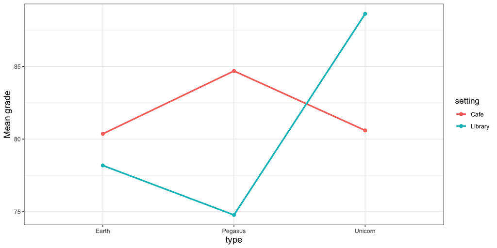

## Two-Way ANOVA: Profile Plots

- We first constructed the profile plot with pony type (*type*) on the *x*-axis and lines for study setting (*setting*).

```r
grades %>% profile_plot(continuous = grade,
                        xaxis = type,
                        lines = setting)
```

- What happens if we switch *xaxis* and *lines*?

```r
grades %>% profile_plot(continuous = grade,
                        xaxis = setting,
                        lines = type)
```

## Two-Way ANOVA: Profile Plots

- Running the code,

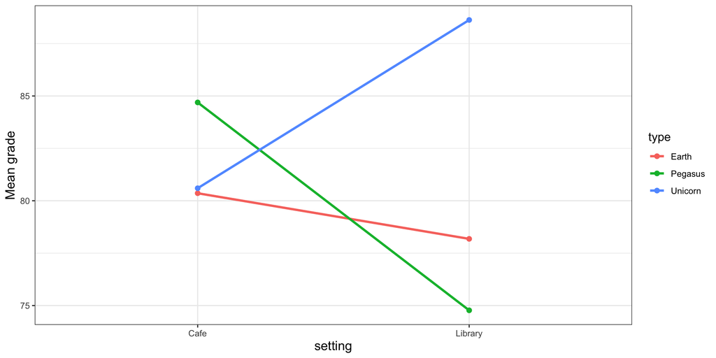

## Two-Way ANOVA: Testing Main Effects

- What if the interaction *is not* significant?
  - We want to *remove* the interaction and examine the *main effects*.
  - That is, we want to look at the individual factors.
- We will reconstruct the ANOVA table. If we were doing this by hand:
  1. Rewrite ANOVA table without interaction; do not change SS, df, and MS for the main effects and total.
  2. Update the error term: add the SS<sub>AB</sub> to SS<sub>E</sub> and df<sub>AB</sub> to df<sub>E</sub>.
  3. Recalculate MS<sub>E</sub>.
  4. Recalculate *F*<sub>A</sub> and *F*<sub>B</sub>, then find the corresponding *p*-values.

## Two-Way ANOVA: Testing Main Effects (R)

- We will use the `two_way_ANOVA()` function from `library(ssstats)` to perform the test for main effects.

```r
dataset_name %>% two_way_ANOVA(continuous = continuous_variable,
                               A = factor_A,
                               B = factor_B,
                               interaction = FALSE,
                               alpha = specified_alpha)
```

## Two-Way ANOVA: Testing Main Effects

- At Ponyville High, students in a general science class (**quiz_scores**) were divided based on their membership in the Science Club (yes/no; *club*) and their primary method of studying outside of school (solo/group; *study*).
- Researchers want to know whether these factors impact science quiz scores (out of 100 points; *score*).
- Let’s first check for an interaction ($\alpha=0.05$). How should we change the following code?

```r
dataset_name %>% two_way_ANOVA(continuous = continuous_variable,
                               A = factor_A,
                               B = factor_B,
                               interaction = TRUE or FALSE,
                               alpha = specified_alpha)
```

## Two-Way ANOVA: Testing Main Effects

- At Ponyville High, students in a general science class (**quiz_scores**) were divided based on their membership in the Science Club (yes/no; *club*) and their primary method of studying outside of school (solo/group; *study*).
- Researchers want to know whether these factors impact science quiz scores (out of 100 points; *score*).
- Let’s first check for an interaction ($\alpha=0.05$). Our updated code,

```r
quiz_scores %>% two_way_ANOVA(continuous = score,
                              A = club,
                              B = study,
                              interaction = TRUE)
```

## Two-Way ANOVA: Testing Main Effects

- Running the code,

```r
quiz_scores %>% two_way_ANOVA(continuous = score,
                              A = club,
                              B = study,
                              interaction = TRUE)
```

```
Test for Interaction (club × study):

H₀: The relationship between score and club does not depend on study.
H₁: The relationship between score and club depends on study.
Test Statistic: F(1, 116) = 0
p-value: p = 0.966
Conclusion: Fail to reject the null hypothesis (p = 0.9656 ≥ α = 0.05)
```

## Two-Way ANOVA: Testing Main Effects

- At Ponyville High, students in a general science class (**quiz_scores**) were divided based on their membership in the Science Club (yes/no; *club*) and their primary method of studying outside of school (solo/group; *study*).
- Researchers want to know whether these factors impact science quiz scores (out of 100 points; *score*).
- Now let’s remove the interaction. How should we update our code?

```r
quiz_scores %>% two_way_ANOVA(continuous = score,
                              A = club,
                              B = study,
                              interaction = TRUE)
```

## Two-Way ANOVA: Testing Main Effects

- At Ponyville High, students in a general science class (**quiz_scores**) were divided based on their membership in the Science Club (yes/no; *club*) and their primary method of studying outside of school (solo/group; *study*).
- Researchers want to know whether these factors impact science quiz scores (out of 100 points; *score*).
- Now let’s remove the interaction. Our updated code,

```r
quiz_scores %>% two_way_ANOVA(continuous = score,
                              A = club,
                              B = study,
                              interaction = FALSE)
```

## Two-Way ANOVA: Testing Main Effects

- **Hypotheses**
  - $H_0:$ $\mu_1$ = $\mu_2$ = … = ($\mu_a$ or $\mu_b$)
  - $H_1:$ At least one $\mu_i$ is different.
- **Test Statistic and *p*-Value**
  - $F_{\text{X}}$ (pull from ANOVA table)
  - $p = P[F_{\text{df}_{\text{X}}, \text{df}_{\text{E}}} \ge F_{\text{X}}]$

## Two-Way ANOVA: Testing Main Effects

- Running the code,

```
Test for Main Effect club:

H₀: μ_Club = μ_No Club
H₁: At least one mean is different.
Test Statistic: F(1, 117) = 11.19
p-value: p = 0.001
Conclusion: Reject the null hypothesis (p = 0.0011 < α = 0.05)

Test for Main Effect study:

H₀: μ_Group = μ_Solo
H₁: At least one mean is different.
Test Statistic: F(1, 117) = 11.24
p-value: p = 0.001
Conclusion: Reject the null hypothesis (p = 0.0011 < α = 0.05)
```

## Two-Way ANOVA: Testing Main Effects

- **Hypotheses**
  - $H_0: \ \mu_{\text{club}} = \mu_{\text{no club}}$
  - $H_1: \ \mu_{\text{club}} \ne \mu_{\text{no club}}$
- **Test Statistic and *p*-Value**
  - $F_{\text{club}} = 11.19$; $p = 0.001$
- **Rejection Region**
  - Reject $H_0$ if $p < \alpha$; $\alpha = 0.05$.
- **Conclusion/Interpretation**
  - Reject $H_0$. There is sufficient evidence to suggest that the quiz grades between those in the science club are different from those not in the science club.

## Two-Way ANOVA: Assumptions

- The ANOVA assumptions we learned last week hold true.
- We assume that the error term follows a normal distribution with mean 0 and a constant variance, $\sigma^2$. i.e.,
  $$\varepsilon_{ij} \overset{\text{iid}}{\sim} N(0, \sigma^2)$$
- Very important note: **the assumption is on the error term** and NOT on the outcome!
- We will use the residual (the difference between the observed value and the predicted value) to assess assumptions:

$$e_{ij} = y_{ij} - \hat{y}_{ij}$$

## Two-Way ANOVA: Assumptions (R)

- We will use the `ANOVA2_assumptions()` function from `library(ssstats)` to request the graphs necessary to asssess our assumptions.

```r
dataset_name %>% ANOVA2_assumptions(continuous = continuous_variable,
                                    A = factor_A,
                                    B = factor_B,
                                    interaction = TRUE or FALSE)
```

## Two-Way ANOVA: Assumptions

- At Ponyville High, students in a general science class (**quiz_scores**) were divided based on their membership in the Science Club (yes/no; *club*) and their primary method of studying outside of school (solo/group; *study*). Researchers want to know whether these factors impact science quiz scores (out of 100 points; *score*).
- Let’s now check the ANOVA assumptions. How should we edit the following code?

```r
dataset_name %>% ANOVA2_assumptions(continuous = continuous_variable,
                                    A = factor_A,
                                    B = factor_B,
                                    interaction = TRUE or FALSE)
```

## Two-Way ANOVA: Assumptions

- At Ponyville High, students in a general science class (**quiz_scores**) were divided based on their membership in the Science Club (yes/no; *club*) and their primary method of studying outside of school (solo/group; *study*). Researchers want to know whether these factors impact science quiz scores (out of 100 points; *score*).
- Let’s now check the ANOVA assumptions. How should we edit the following code?

```r
dataset_name %>% ANOVA2_assumptions(continuous = continuous_variable,
                                    A = factor_A,
                                    B = factor_B,
                                    interaction = TRUE or FALSE)
```

## Two-Way ANOVA: Assumptions

- At Ponyville High, students in a general science class (**quiz_scores**) were divided based on their membership in the Science Club (yes/no; *club*) and their primary method of studying outside of school (solo/group; *study*). Researchers want to know whether these factors impact science quiz scores (out of 100 points; *score*).
- Let’s now check the ANOVA assumptions. Our updated code,

```r
quiz_scores %>% ANOVA2_assumptions(continuous = score,
                                  A = club,
                                  B = study,
                                  interaction = TRUE)
```

## Two-Way ANOVA: Assumptions

- Running the code,

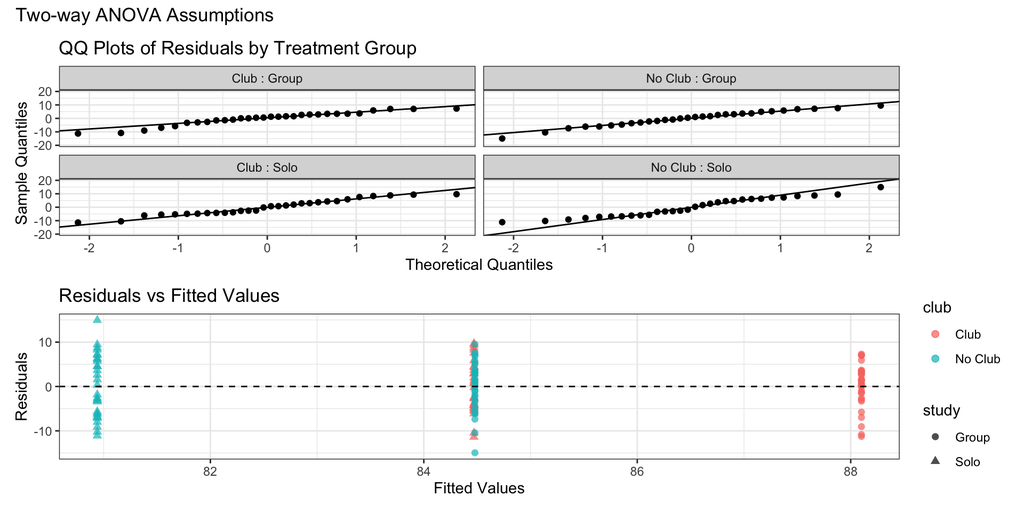

## Wrap Up

- Today we have covered two-way ANOVA.
  - Two-way ANOVA table
  - Testing interactions
  - Testing main effects (only when interaction is not present)
  - Profile plot (plot of group means)
  - ANOVA assumptions
- Note about nonparametric two-way ANOVA.
  - Methodology is “newish” - we are not covering.

## Wrap Up

- Next week:
  - Meeting 1:
    - Lab: two-way ANOVA
    - Quiz: two-way ANOVA
  - Meeting 2:
    - Module 2 review
    - Project 2
    - Quiz: Module 2